# Bayesian Spatiotemporal Analysis of Ozone Pollution in California

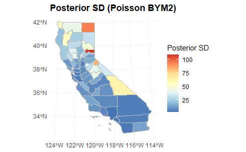

```r
### Posterior SD map (Poisson)

pb_sd <- ggplot(sf_b) +
  geom_sf(aes(fill = fit_sd_rate), color = "grey", linewidth = 0.01) +
  scale_fill_distiller(
    name = "Posterior SD",
    palette = "RdYlBu",
    direction = -1
  ) +
  labs(title = "Posterior SD (Poisson BYM2)") +
  theme_minimal() +
  theme(
    legend.position = "right",
    plot.title = element_text(face = "bold"),
    panel.grid.major = element_line(linewidth = 0.1, linetype = "dotted")
  )
pb_sd
```

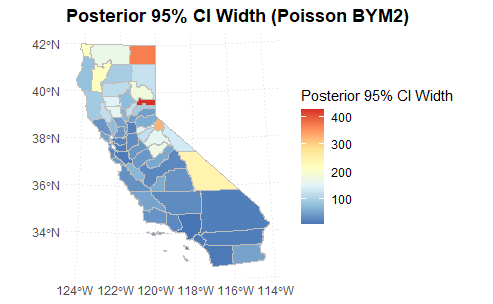

```r
### Posterior CI width map (Poisson)

pb_ci <- ggplot(sf_b) +
  geom_sf(aes(fill = fit_ci_rate), color = "grey", linewidth = 0.01) +
  scale_fill_distiller(
    name = "Posterior 95% CI Width",
    palette = "RdYlBu",
    direction = -1
  ) +
  labs(title = "Posterior 95% CI Width (Poisson BYM2)") +
  theme_minimal() +
  theme(
    legend.position = "right",
    plot.title = element_text(face = "bold"),
    panel.grid.major = element_line(linewidth = 0.1, linetype = "dotted")
  )
pb_ci
```

```r
### Diagnostics - Gaussian model

### R-Squared (Gaussian model)

y_obs_gauss <- df_model_annual[[resp_var]]

y_hat_gauss <- fit_a$summary.fitted.values$mean

r_squared_gauss <- cor(
  y_obs_gauss,
  y_hat_gauss,
  use = "complete.obs")^2

print(paste("Gaussian R-Squared: ", round(r_squared_gauss, 3)))
```

```
[1] "Gaussian R-Squared:  0.26"
```

```r
### RMSE (Gaussian model)

rmse_gauss <- sqrt(mean(
  (df_model_annual[[resp_var]] - fit_a$summary.fitted.values$mean)^2,
  na.rm = T
))
print(paste("Gaussian RMSE: ", round(rmse_gauss, 3)))
```

```
[1] "Gaussian RMSE:  194.246"
```

```r
### 95% Predictive Coverage (Gaussian model)

coverage95_gauss <- mean(
  df_model_annual[[resp_var]] >= fit_a$summary.fitted.values$`0.025quant` &
  df_model_annual[[resp_var]] <= fit_a$summary.fitted.values$`0.975quant`,
  na.rm = T
)
print(paste("Gaussian 95% coverage: ", round(coverage95_gauss, 3)))
```

```
[1] "Gaussian 95% coverage:  0.345"
```

```r
### DIC (Gaussian model)

print(paste("Gaussian DIC: ", round(fit_a$dic$dic, 3)))
```

```
[1] "Gaussian DIC:  779.109"
```

```r
### WAIC (Gaussian model)

print(paste("Gaussian WAIC: ", round(fit_a$waic$waic, 3)))
```

```
[1] "Gaussian WAIC:  779.444"
```

```r
### Diagnostics - Poisson model

y_obs_rate <- df_model_annual[[resp_var]]

pop_vec <- fc_no_geom$TOT_POP

mu_hat_pois <- fit_b$summary.fitted.values$mean

lcl_pois <- fit_b$summary.fitted.values$`0.025quant`

ucl_pois <- fit_b$summary.fitted.values$`0.975quant`

### Convert expected counts and intervals to rates

y_hat_pois_rate <- (mu_hat_pois / pop_vec) * 1e5

lcl_pois_rate <- (lcl_pois / pop_vec) * 1e5

ucl_pois_rate <- (ucl_pois / pop_vec) * 1e5

### R-Squared (Poisson model)

y_obs_rate <- df_model_annual[[resp_var]]

y_hat_pois_rate <- (fit_b$summary.fitted.values$mean / fc_no_geom$TOT_POP) * 1e5

r_squared_pois <- cor(
  y_obs_rate,
  y_hat_pois_rate,
  use = "complete.obs")^2

print(paste("Poisson R-Squared (rate scale): ", round(r_squared_pois, 3)))
```

```
[1] "Poisson R-Squared (rate scale):  0.962"
```

```r
### RMSE (Poisson model)

rmse_pois <- sqrt(mean(
  (y_obs_rate - y_hat_pois_rate)^2,
  na.rm = T
))
print(paste("Poisson RMSE: ", round(rmse_pois, 3)))
```

```
[1] "Poisson RMSE:  40.42"
```

```r
### 95% Predictive Coverage (Poisson model)

coverage95_pois <- mean(
  y_obs_rate >= lcl_pois_rate &
    y_obs_rate <= ucl_pois_rate,
  na.rm = T
)
print(paste("Poisson 95% coverage: ", round(coverage95_pois, 3)))
```

```
[1] "Poisson 95% coverage:  0.983"
```

```r
### DIC (Poisson model)

print(paste("Poisson DIC: ", round(fit_b$dic$dic, 3)))
```

```
[1] "Poisson DIC:  612.796"
```

```r
### WAIC (Poisson model)

print(paste("Poisson WAIC: ", round(fit_b$waic$waic, 3)))
```

```
[1] "Poisson WAIC:  599.94"
```

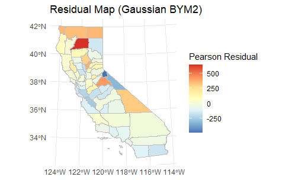

```r
### Residual diagnostics for Gaussian model

### Compute residuals in the model frame

df_model_annual$residuals <- df_model_annual[[resp_var]] -
  fit_a$summary.fitted.values$mean

sf_resid <- fc_df

sf_resid$residuals <- df_model_annual$residuals

ggplot(sf_resid) +
  geom_sf(aes(fill = residuals), color="grey", linewidth = 0.01) +
  scale_fill_distiller(palette = "RdYlBu") +
  labs(title="Residual Map (Gaussian BYM2)", fill = "Pearson Residual") +
  theme_minimal()
```

```r
### Spatial autocorrelation in residuals

nb_resid <- poly2nb(as_Spatial(fc_df))
lw_resid <- nb2listw(nb_resid, style = "W", zero.policy = T)

moran_res <- moran.test(sf_resid$residuals, lw_resid, zero.policy = T)

print(moran_res)
```

```
    Moran I test under randomisation

data:  sf_resid$residuals
weights: lw_resid

Moran I statistic standard deviate = 2.5146,
p-value = 0.005959
alternative hypothesis: greater
sample estimates:
Moran I statistic       Expectation          Variance
      0.190442815      -0.017543860       0.006841429
```

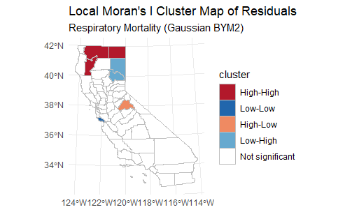

```r
### Local Moran's I

lm_res <- localmoran(sf_resid$residuals,
                     lw_resid,
                     zero.policy = T)

### Add results to the sf object

sf_resid$Ii <- lm_res[, "Ii"]
sf_resid$Z_Ii <- lm_res[, "Z.Ii"]
sf_resid$p_Ii <- 2 * pnorm(-abs(sf_resid$Z_Ii))

### Spatial lag of residuals

lag_resid <- lag.listw(lw_resid,
                       sf_resid$residuals,
                       zero.policy = T)

mean_resid <- mean(sf_resid$residuals, na.rm = T)

mean_lag <- mean(lag_resid, na.rm = T)

sf_resid$cluster <- "Not significant"

sig <- sf_resid$p_Ii <= 0.05

sf_resid$cluster[sig & sf_resid$residuals >  mean_resid & lag_resid >  mean_lag] <- "High-High"
sf_resid$cluster[sig & sf_resid$residuals <  mean_resid & lag_resid <  mean_lag] <- "Low-Low"
sf_resid$cluster[sig & sf_resid$residuals >  mean_resid & lag_resid <  mean_lag] <- "High-Low"
sf_resid$cluster[sig & sf_resid$residuals <  mean_resid & lag_resid >  mean_lag] <- "Low-High"

sf_resid$cluster <- factor(
  sf_resid$cluster,
  levels = c("High-High", "Low-Low", "High-Low", "Low-High", "Not significant"))

### Local Moran's I plot

ggplot(sf_resid) +
  geom_sf(aes(fill = cluster), color = "grey", linewidth = 0.01) +
  scale_fill_manual(
    name = "cluster",
    values = c(
      "High-High" = "#b2182b",
      "Low-Low" = "#2166ac",
      "High-Low" = "#ef8a62",
      "Low-High" = "#67a9cf",
      "Not significant"= "white"
    )) +
  labs (
    title = "Local Moran's I Cluster Map of Residuals",
    subtitle = "Respiratory Mortality (Gaussian BYM2)"
  ) +
  theme_minimal()
```

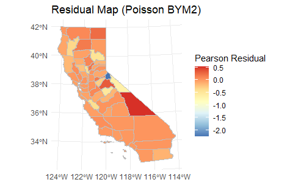

```r
### Pearson residuals for Poisson model

### Observed counts and fitted counts

y_count   <- fc_no_geom$resp_deaths

mu_hat_b  <- fit_b$summary.fitted.values$mean

### Pearson residuals

df_model_annual$resid_pois <- (y_count - mu_hat_b) / sqrt(mu_hat_b)

sf_resid_p <- fc_df

sf_resid_p$resid_pois <- df_model_annual$resid_pois

### Residual map

ggplot(sf_resid_p) +
  geom_sf(aes(fill = resid_pois), color = "grey", linewidth = 0.01) +
  scale_fill_distiller(palette = "RdYlBu") +
  labs(
    title = "Residual Map (Poisson BYM2)",
    fill  = "Pearson Residual"
  ) +
  theme_minimal()
```

```r
### Spatial autocorrelation in Poisson residuals

nb_resid <- poly2nb(as_Spatial(fc_df))
lw_resid <- nb2listw(nb_resid, style = "W", zero.policy = T)

moran_res_pois <- moran.test(sf_resid_p$resid_pois, lw_resid, zero.policy = T)
print(moran_res_pois)
```

```
    Moran I test under randomisation

data:  sf_resid_p$resid_pois
weights: lw_resid

Moran I statistic standard deviate = 0.029455,
p-value = 0.4883
alternative hypothesis: greater
sample estimates:
Moran I statistic       Expectation          Variance
     -0.015739415      -0.017543860       0.003752881
```

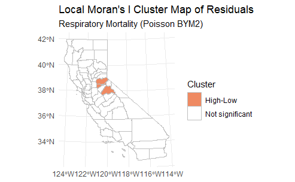

```r
### Local Moran's I for Poisson residuals

lm_res_p <- localmoran(sf_resid_p$resid_pois,
                       lw_resid,
                       zero.policy = T)

sf_resid_p$Ii   <- lm_res_p[, "Ii"]
sf_resid_p$Z_Ii <- lm_res_p[, "Z.Ii"]
sf_resid_p$p_Ii <- 2 * pnorm(-abs(sf_resid_p$Z_Ii))

### Spatial lag of residuals

lag_resid_p <- lag.listw(lw_resid,
                         sf_resid_p$resid_pois,
                         zero.policy = T)

mean_resid_p <- mean(sf_resid_p$resid_pois, na.rm = T)
mean_lag_p <- mean(lag_resid_p, na.rm = T)

sf_resid_p$cluster <- "Not significant"
sig_p <- sf_resid_p$p_Ii <= 0.05

sf_resid_p$cluster[sig_p & sf_resid_p$resid_pois >  mean_resid_p & lag_resid_p >  mean_lag_p] <- "High-High"
sf_resid_p$cluster[sig_p & sf_resid_p$resid_pois <  mean_resid_p & lag_resid_p <  mean_lag_p] <- "Low-Low"
sf_resid_p$cluster[sig_p & sf_resid_p$resid_pois >  mean_resid_p & lag_resid_p <  mean_lag_p] <- "High-Low"
sf_resid_p$cluster[sig_p & sf_resid_p$resid_pois <  mean_resid_p & lag_resid_p >  mean_lag_p] <- "Low-High"

sf_resid_p$cluster <- factor(
  sf_resid_p$cluster,
  levels = c("High-High", "Low-Low", "High-Low", "Low-High", "Not significant")
)

ggplot(sf_resid_p) +
  geom_sf(aes(fill = cluster), color = "grey", linewidth = 0.01) +
  scale_fill_manual(
    name = "Cluster",
    values = c(
      "High-High" = "#b2182b",
      "Low-Low" = "#2166ac",
      "High-Low"= "#ef8a62",
      "Low-High" = "#67a9cf",
      "Not significant" = "white"
    )
  ) +
  labs(
    title = "Local Moran's I Cluster Map of Residuals",
    subtitle = "Respiratory Mortality (Poisson BYM2)"
  ) +
  theme_minimal()
```

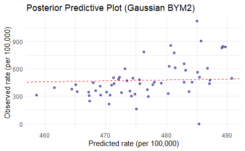

```r
### Posterior predictive distribution vs observed

post_mean <- fit_a$summary.fitted.values$mean

ggplot() +
  geom_point(aes(x = post_mean, y = df_model_annual[[resp_var]]),
             color = "navy", alpha = 0.5) +
  geom_abline(slope = 1, intercept = 0, color = "red", linetype = "dashed") +
  labs(
    title = "Posterior Predictive Plot (Gaussian BYM2)",
    x = "Predicted rate (per 100,000)",
    y = "Observed rate (per 100,000)"
  ) +
  theme_minimal()
```

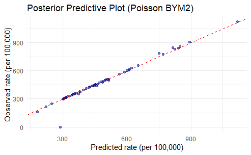

```r
### Predicted rate from Poisson (per 100,000)

lp_b <- fit_b$summary.linear.predictor
mu_hat_b <- exp(lp_b$mean)

pop_vec <- fc_no_geom$TOT_POP
y_hat_rate_pois <- (mu_hat_b / pop_vec) * 1e5
y_obs_rate <- df_model_annual[[resp_var]]

ggplot() +
  geom_point(aes(x = y_hat_rate_pois, y = y_obs_rate),
             color = "navy", alpha = 0.5) +
  geom_abline(slope = 1, intercept = 0,
              color = "red", linetype = "dashed") +
  labs(
    title = "Posterior Predictive Plot (Poisson BYM2)",
    x = "Predicted rate (per 100,000)",
    y = "Observed rate (per 100,000)"
  ) +
  theme_minimal()
```

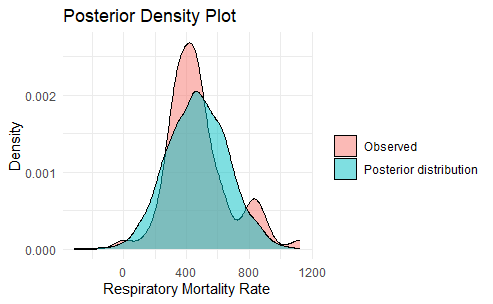

```r
### Posterior predictive density for respiratory mortality rate

### Set seed for reproducability

set.seed(123)

### Extract fitted means

sum_a <- fit_a$summary.fitted.values

### Observed respiratory mortality

y_obs <- df_model_annual[[resp_var]]

### Sample from the posterior

prec_marg <- fit_a$marginals.hyperpar[["Precision for the Gaussian observations"]]

n_samp <- 5000

prec_samp <- inla.rmarginal(n_samp, prec_marg)

sigma_samp <- 1 / sqrt(prec_samp)

### Combine with the fitted means to generate posterior predictive draws

n_areas <- nrow(sum_a)

idx_samp <- sample.int(n_areas, size = n_samp, replace = T)

mu_samp <- sum_a$mean[idx_samp]

y_rep <- rnorm(n_samp, mean = mu_samp, sd = sigma_samp)

### Build data frames for plotting

df_post <- data.frame(
  value = y_rep,
  type = "Posterior distribution"
)

df_obs <- data.frame(
  value = y_obs,
  type  = "Observed"
)

df_plot <- rbind(df_post, df_obs)

### Density plot: posterior predictive vs observed

ggplot(df_plot, aes(x = value, fill = type)) +
  geom_density(alpha = 0.5) +
  labs(
    title = "Posterior Density Plot",
    x = "Respiratory Mortality Rate",
    y = "Density",
    fill  = ""
  ) +
  theme_minimal()
```

**These findings suggest that Poisson spatial model is more appropriate for county level mortality modeling and should be favored in future environmental health analyses and research. In future work, incorporating multiple years of NASA TEMPO ozone data, validating ozone conversion methods, integrating detailed socioeconomic indicators, and expanding to fully spatiotemporal Bayesian models could provide a more detailed understanding of air pollution interaction with demographic and climatic factors to influence respiratory health across California.**